# Real Data (Summary)

### Check correlation

- EastAsia and White are highly correlated with a p-value < 0.05 from both Chi-square test/Fisher’s exact test. $R^2$ of logistic model with EastAsia as an outcome, adjusted for the rest predictors is 0.76.
- We keep **White** and remove EastAsia from the covariates in the propensity model
  - logit fit with EastAsia and the other covariates in the model: coefficient of EastAsia -3.51
  - logit fit with White and the other covariates in the model: coefficient of White 2.47
- Frequency Table with White(=1,=0) as rows, EastAsia (=1,=0) as columns

```
##
##       0   1
##   0  43 159
##   1 610   0
```

```
## D ~ Smoker + AGE + WEIGHTBL + BASETMR + Male + PRAD_ind + White +
##     PDL1TPS_50 + BSECOG
```

```
##
## Call:
## glm(formula = ps.fml, family = "binomial", data = complete.dt)
##
## Deviance Residuals:
##     Min       1Q   Median       3Q      Max
## -1.8688  -1.0757  -0.2954   0.9536   2.5813
##
## Coefficients:
##              Estimate Std. Error z value Pr(>|z|)
## (Intercept) -2.824873   0.729255  -3.874 0.000107 ***
## Smoker       0.964275   0.232578   4.146 3.38e-05 ***
## AGE         -0.001304   0.008837  -0.148 0.882688
## WEIGHTBL     0.010919   0.006156   1.774 0.076085 .
## BASETMR     -0.002135   0.001251  -1.706 0.087944 .
## Male        -0.464446   0.190107  -2.443 0.014563 *
## PRAD_ind     0.227292   0.217612   1.044 0.296262
## White        2.471096   0.275677   8.964  < 2e-16 ***
## PDL1TPS_50   0.178988   0.162127   1.104 0.269593
## BSECOG      -0.572285   0.171535  -3.336 0.000849 ***
## ---
## Signif. codes:  0 '***' 0.001 '**' 0.01 '*' 0.05 '.' 0.1 ' ' 1
##
## (Dispersion parameter for binomial family taken to be 1)
##
##     Null deviance: 1124.07  on 811  degrees of freedom
## Residual deviance:  898.72  on 802  degrees of freedom
## AIC: 918.72
##
## Number of Fisher Scoring iterations: 5
```

```
## Z ~ Smoker + AGE + WEIGHTBL + BASETMR + Male + PRAD_ind + White +
##     PDL1TPS_50 + BSECOG
```

```
##
## Call:
## glm(formula = ps.fml.Z, family = "binomial", data = complete.dt)
##
## Deviance Residuals:
##     Min       1Q   Median       3Q      Max
## -1.5244  -0.9466  -0.3867   1.1418   2.5655
##
## Coefficients:
##              Estimate Std. Error z value Pr(>|z|)
## (Intercept) -3.315545   0.751505  -4.412 1.02e-05 ***
## Smoker       0.709364   0.248847   2.851 0.004364 **
## AGE          0.002483   0.009012   0.276 0.782898
## WEIGHTBL     0.010148   0.006037   1.681 0.092790 .
## BASETMR     -0.002494   0.001311  -1.903 0.057002 .
## Male        -0.091098   0.188413  -0.484 0.628738
## PRAD_ind     0.123893   0.214667   0.577 0.563843
## White        2.061645   0.313746   6.571 5.00e-11 ***
## PDL1TPS_50   0.054424   0.162774   0.334 0.738113
## BSECOG      -0.625589   0.168154  -3.720 0.000199 ***
## ---
## Signif. codes:  0 '***' 0.001 '**' 0.01 '*' 0.05 '.' 0.1 ' ' 1
##
## (Dispersion parameter for binomial family taken to be 1)
##
##     Null deviance: 1018.28  on 811  degrees of freedom
## Residual deviance:  887.83  on 802  degrees of freedom
## AIC: 907.83
##
## Number of Fisher Scoring iterations: 5
```

```
## Y ~ Smoker + AGE + WEIGHTBL + BASETMR + Male + PRAD_ind + White +
##     PDL1TPS_50 + BSECOG + Z + D
```

```
##
## Call:
## glm(formula = outcome.fml, family = "binomial", data = mydata)
##
## Deviance Residuals:
##     Min       1Q   Median       3Q      Max
## -1.6347  -0.9103  -0.6690   1.1750   2.0940
##
## Coefficients:
##              Estimate Std. Error z value Pr(>|z|)
## (Intercept) -1.117530   0.670105  -1.668  0.09538 .
## Smoker      -0.029912   0.213197  -0.140  0.88842
## AGE          0.005362   0.008308   0.645  0.51872
## WEIGHTBL     0.006855   0.005981   1.146  0.25176
## BASETMR     -0.004122   0.001316  -3.133  0.00173 **
## Male        -0.263293   0.183509  -1.435  0.15135
## PRAD_ind     0.278837   0.207148   1.346  0.17828
## White       -0.106386   0.220149  -0.483  0.62892
## PDL1TPS_50   0.639882   0.156364   4.092 4.27e-05 ***
## BSECOG      -0.393974   0.161504  -2.439  0.01471 *
## Z            1.185828   0.248411   4.774 1.81e-06 ***
## D           -0.369215   0.254665  -1.450  0.14711
## ---
## Signif. codes:  0 '***' 0.001 '**' 0.01 '*' 0.05 '.' 0.1 ' ' 1
##
## (Dispersion parameter for binomial family taken to be 1)
##
##     Null deviance: 1054.88  on 811  degrees of freedom
## Residual deviance:  975.42  on 800  degrees of freedom
## AIC: 999.42
##
## Number of Fisher Scoring iterations: 4
```

## Figure 1: PS approach Diagnosis (By trial)

### Figure 1A: All patients

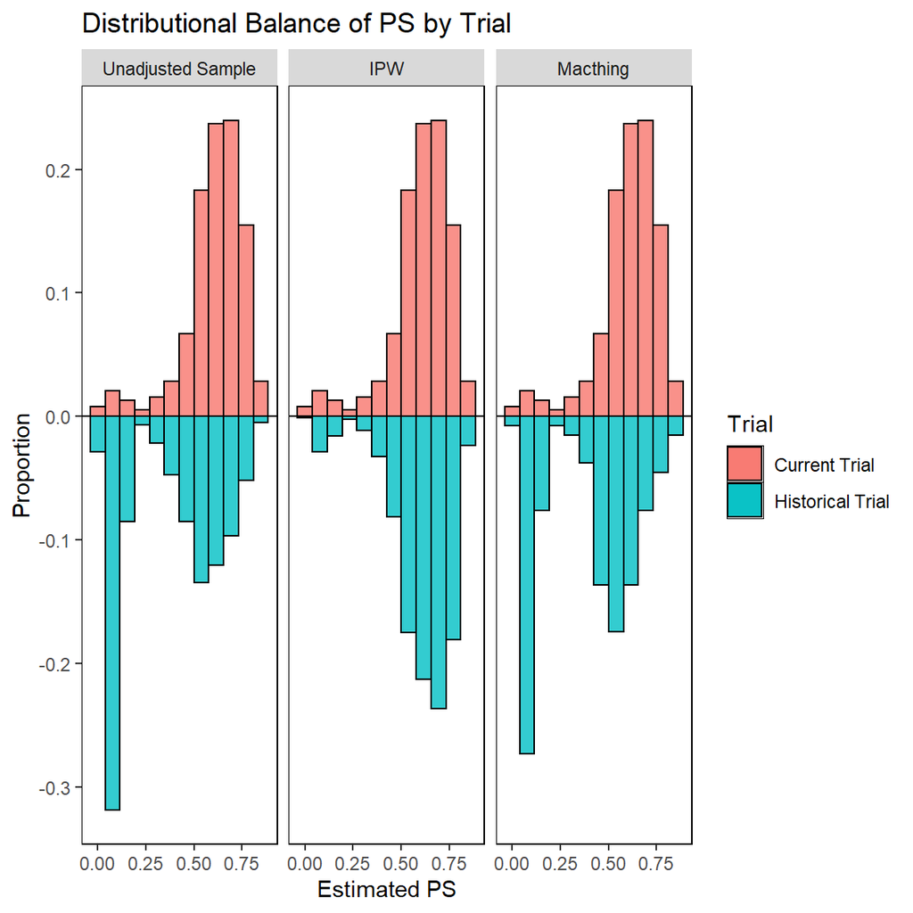

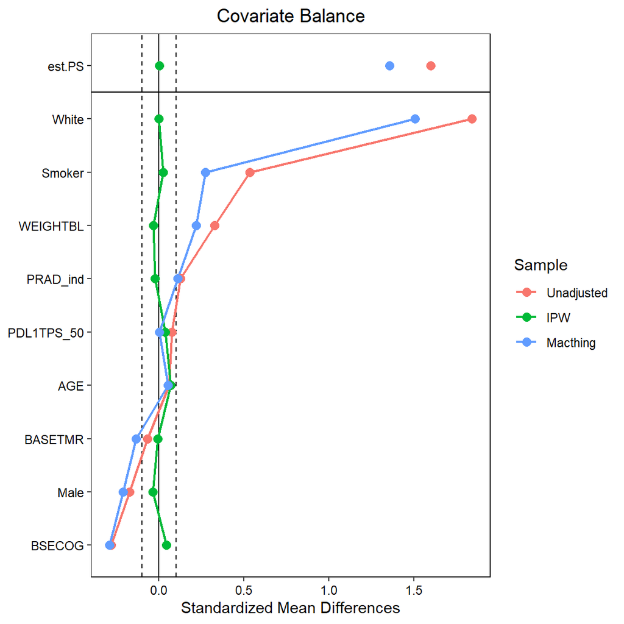

### Figure 1.2: White subgroup

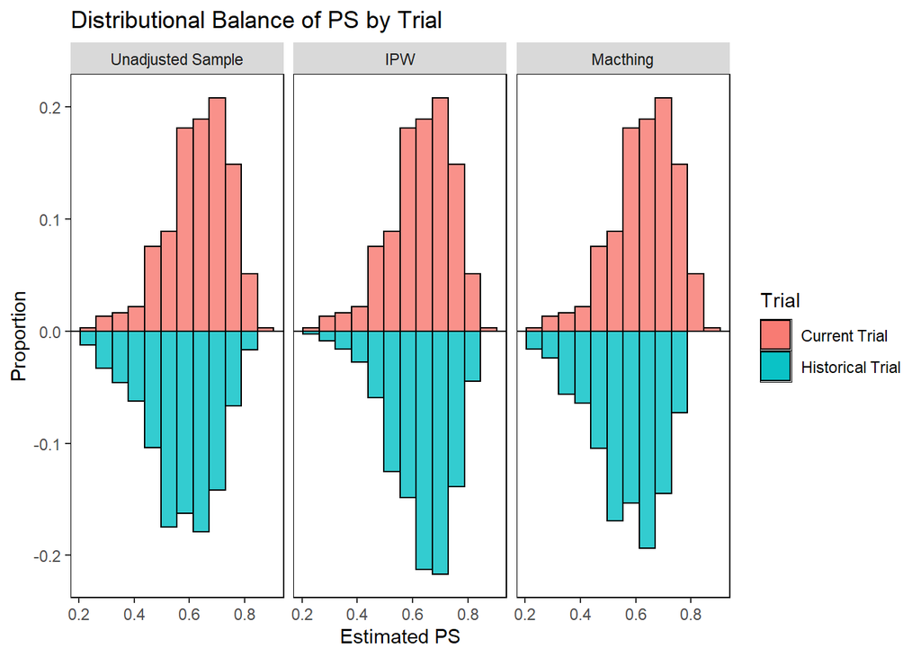

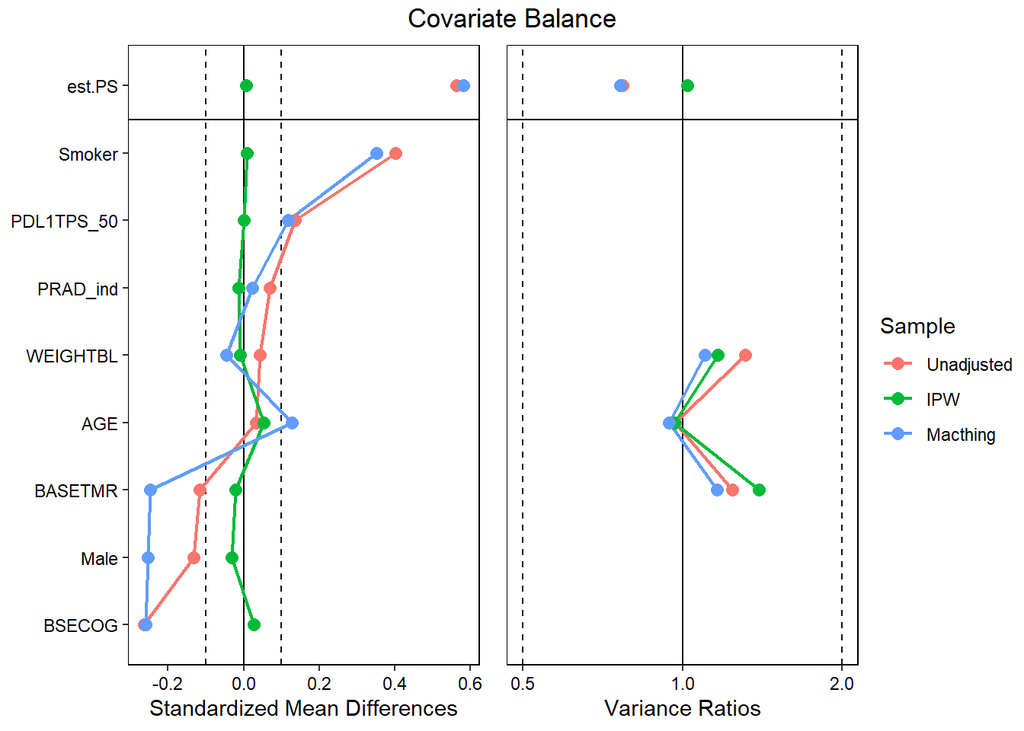